# Exercise Prediction

March 27, 2016

## Purpose

While sensors collect a large amount of data about how much of a particular activity people do, these tools rarely quantify how well they do it.

This analysis will use data from accelerometers on the belt, forearm, arm, and dumbell of 6 participants. These participants were asked to perform barbell lifts correctly and incorrectly in 5 different ways.

The goal of this analysis is to predict the manner in which participants did the exercise, indicated by the `classe` variable.

## Data

Information on the data collection design is available from the [Human Activity Recognition](http://groupware.les.inf.puc-rio.br/har) website (*see the section on the Weight Lifting Exercise Dataset*).

### Reading it in

We read in the training and testing data files from the site referenced above:

```r
library(caret)

training <- read.csv("https://d396qusza40orc.cloudfront.net/predmachlearn/pml-training.csv",
                     na.strings = c("NA",""," "))

testing <- read.csv("https://d396qusza40orc.cloudfront.net/predmachlearn/pml-testing.csv",
                    na.strings = c("NA",""," "))
```

### Munging

```r
training <- training[, colSums(is.na(training)) <= (0.10 * nrow(training))]
```

… and columns with zero or near-zero variance

```r
nzv <- nearZeroVar(training)
training <- training[, -nzv]

print(paste0("Removed ", length(nzv), " columns with near-zero variance."))
```

```
## [1] "Removed 1 columns with near-zero variance."
```

… and other factor and index columns

```r
library(dplyr); library(magrittr)
training %<>% select(-X, -user_name, -raw_timestamp_part_1,
                     -raw_timestamp_part_2, -cvtd_timestamp,
                     -num_window)
```

We then removed descriptors with absolute correlations above 0.9 :

```r
descrCor <-  cor(training %>% select(-classe))

highlyCorDescr <- findCorrelation(descrCor, cutoff = .9)

training <- training[,-highlyCorDescr]
```

This leaves us with 46 variables.

## How the model was built

### Cross-validation

#### Split training set into training/testing subsets

Our first step is to partition the training data so that we can use it on testing, while holding out the test set for validation.

```r
library(caret)

trainIndex <- createDataPartition(training$classe, p = 0.7, list = FALSE)
train_train <- training[trainIndex,]
train_test <- training[-trainIndex,]
```

## Training Models

First, we’ll define some controls for the training function:

```r
fitControl <- trainControl(method = "cv",
                           number = 10,
                           repeats = 3,
                           selectionFunction = "best")
```

Setting these parameters allows us to do cross-validation across multiple folds and to build a model on each training subset and then evaluate on each test subset. Here, we select the “best” model because we’re aiming for one-shot accuracy in the class rather than scalability.

Then we’ll build several models for comparison: (*Note: To avoid timely processing, the model were run using the commented out commands and saved locally, then loaded to produce the markdown file.*)

### Decision tree

```r
set.seed(123)
modelFit_tree <- train(classe ~ .,
                       data = train_train,
                       method = "rpart",
                       trControl = fitControl)

# saveRDS(modelFit_tree, "modelFit_tree.rds")
#
# modelFit_tree <- readRDS("modelFit_tree.rds")
```

### Random forest

```r
set.seed(123)
modelFit_rf <- train(classe ~ .,
                     data = train_train,
                     method = "rf",
                     trControl = fitControl)

# saveRDS(modelFit_rf, "modelFit_rf.rds")
#
# modelFit_rf <- readRDS("modelFit_rf.rds")
```

### Support vector machine (SVM)

```r
set.seed(123)
modelFit_svm <- train(classe ~ .,
                      data = train_train,
                      method = "svmRadial",
                      trControl = fitControl)

# saveRDS(modelFit_svm, "modelFit_svm.rds")
#
# modelFit_svm <- readRDS("modelFit_svm.rds")
```

### Generalized Boosted Regression Model (GBM)

```r
set.seed(123)
modelFit_gbm <- train(classe ~ .,
                     data = train_train,
                     method = "gbm",
                     trControl = fitControl)

# saveRDS(modelFit_gbm, "modelFit_gbm.rds")
#
# modelFit_gbm <- readRDS("modelFit_gbm.rds")
```

### Comparison of Models

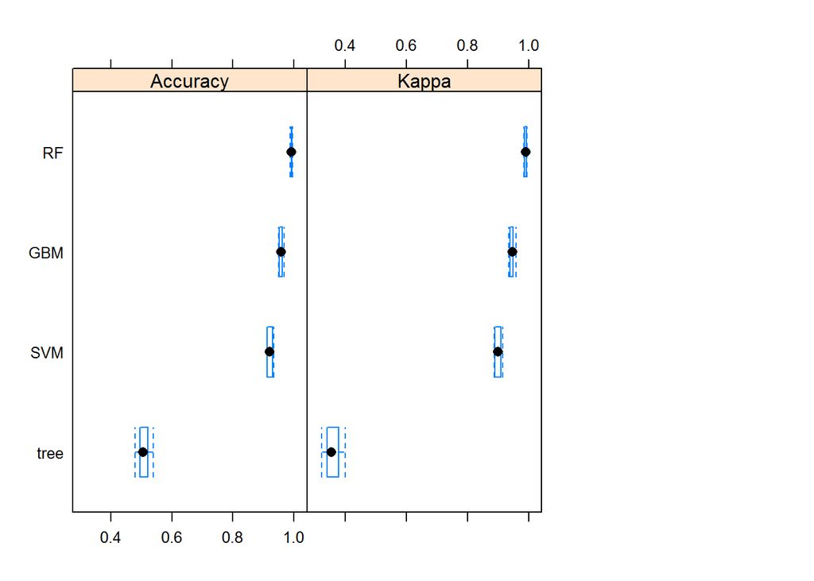

```r
results <- resamples(list(tree = modelFit_tree,
                          RF = modelFit_rf,
                          SVM = modelFit_svm,
                          GBM = modelFit_gbm))

# summary(results)
bwplot(results, layout = c(3, 1))
```

The importance of variables contributing to this model is shown below:

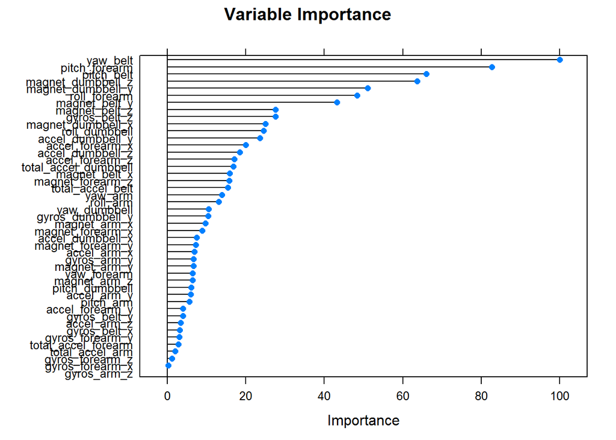

```r
varImp(modelFit_rf, scale = FALSE)
varImpObj <- varImp(modelFit_rf)
plot(varImpObj, main = "Variable Importance")
```

## Applying Model to Test Set

Finally, we apply our prediction model to predict the testing dataset.

```r
predict_test <- predict(modelFit_rf, newdata = testing)

testing$predict <- predict_test

submit <- testing %>% select(problem_id, predict)
```